# Question

En una clase de antropometría, se midió la estatura (en cm) de un grupo de estudiantes. Las dimensiones del cuerpo humano varían de acuerdo al sexo, edad, raza, nivel socioeconómico, etc.; por lo que esta ciencia dedicada a investigar, recopilar y analizar estos datos resulta fundamental en diversos campos.

Los datos de estatura se muestran en la siguiente tabla:

Datos de estaturas

| Dato | Estatura.en..cm. |
| --- | --- |
| 1 | 158 |
| 2 | 175 |
| 3 | 169 |
| 4 | 173 |
| 5 | 154 |
| 6 | 177 |
| 7 | 162 |
| 8 | 165 |
| 9 | 147 |
| 10 | 163 |
| 11 | 164 |
| 12 | 153 |
| 13 | 170 |

¿Cuál de los siguientes diagramas de caja (boxplots) representa correctamente la estatura de los estudiantes?

## Answerlist

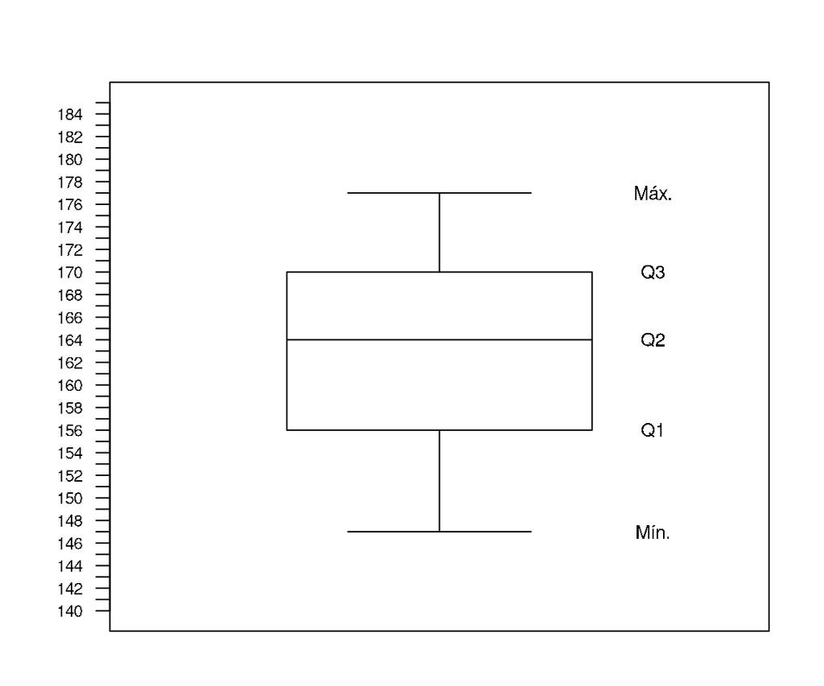

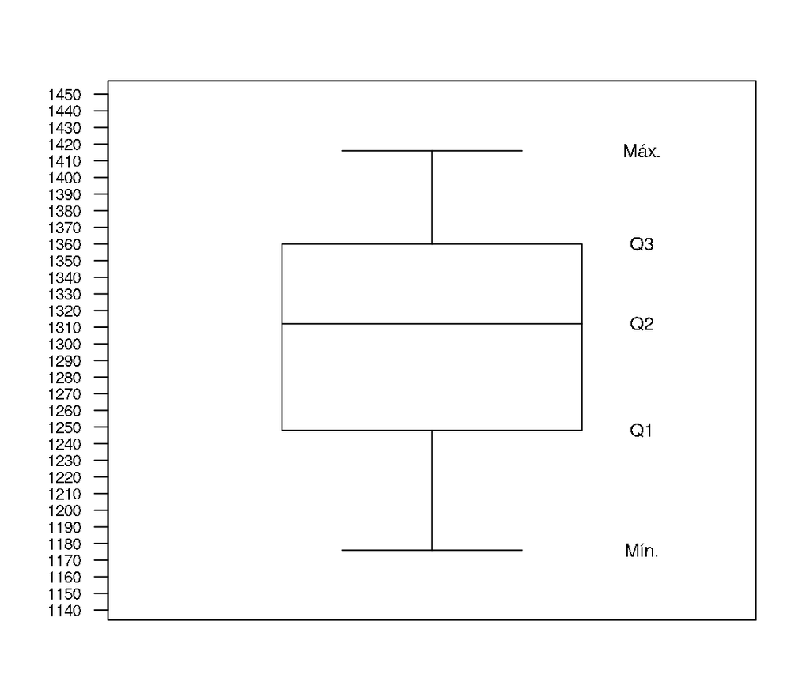

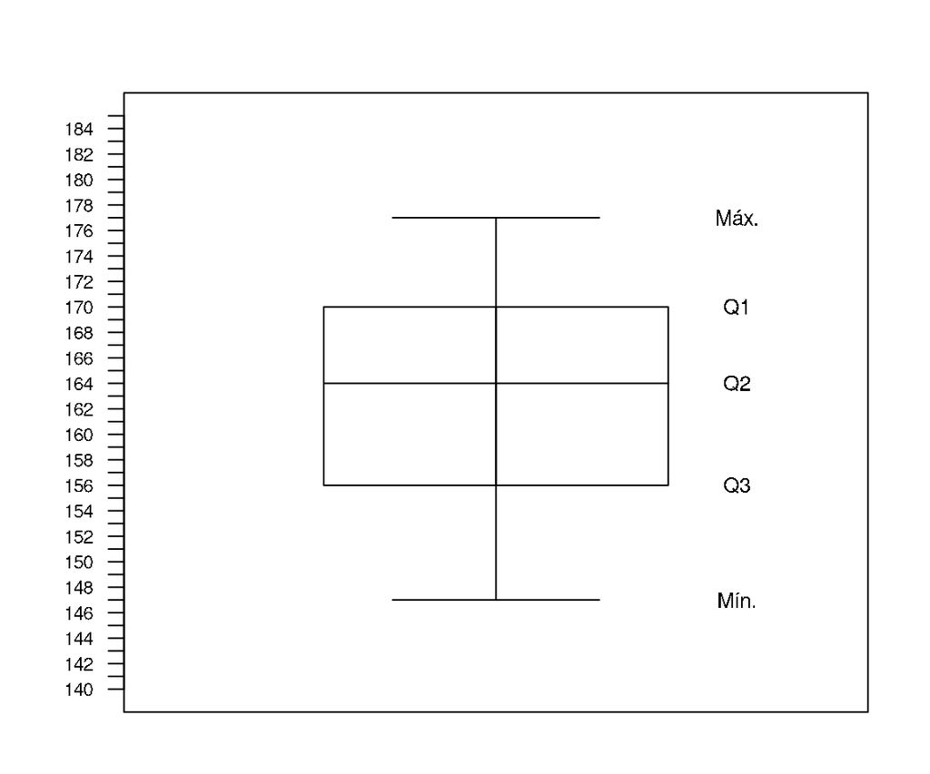

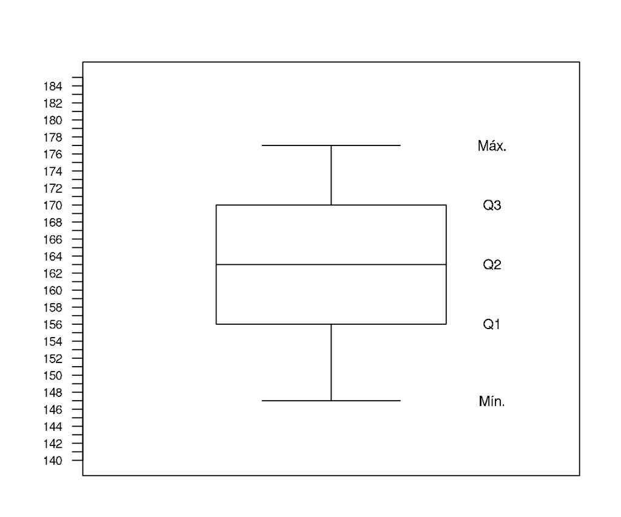

# Solution

Para determinar cuál diagrama de caja representa correctamente los datos, necesitamos identificar las estadísticas principales:

Estadísticas calculadas de las estaturas

[output not shown]

Analizando cada diagrama, el correcto es el que muestra:

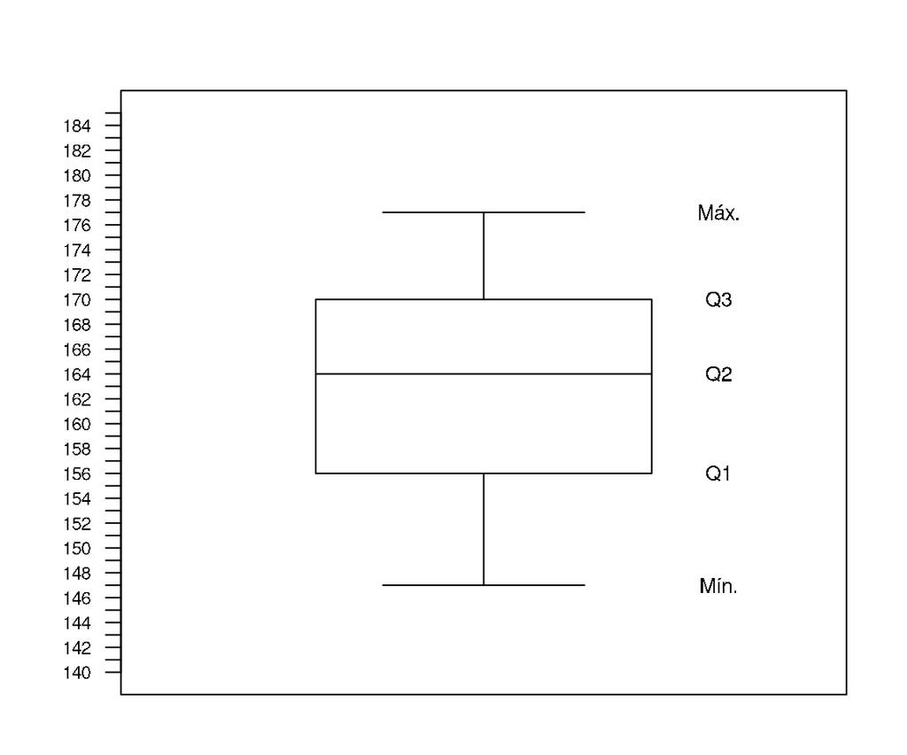

Los diagramas incorrectos presentan alguna de estas alteraciones:

- Valores multiplicados por un factor (generando una escala diferente)
- Cuartiles Q1 y Q3 invertidos
- Mediana calculada incorrectamente (ya sea como la media entre el valor mínimo y máximo, la media entre Q1 y Q3, o un valor aleatorio entre Q1 y Q3)

# Answerlist

# Meta-information

exname: Cuartiles en Diagrama de Caja de Estaturas extype: schoice exsolution: 1000 exshuffle: true